# Alternative Clustering

### Introduction

K-Means Clustering is the most popular algorithm for clustering analysis. However, it has limitations including:

- User specifies the number of clusters in advance
- Initial centroids are randomly selected

Below we explore some alternative strategies that intend to overcome the limitations.

### Hierarchical K-Means Clustering

A hybrid method called Hierarchical K-Means Clustering improved upon the base K-Means.

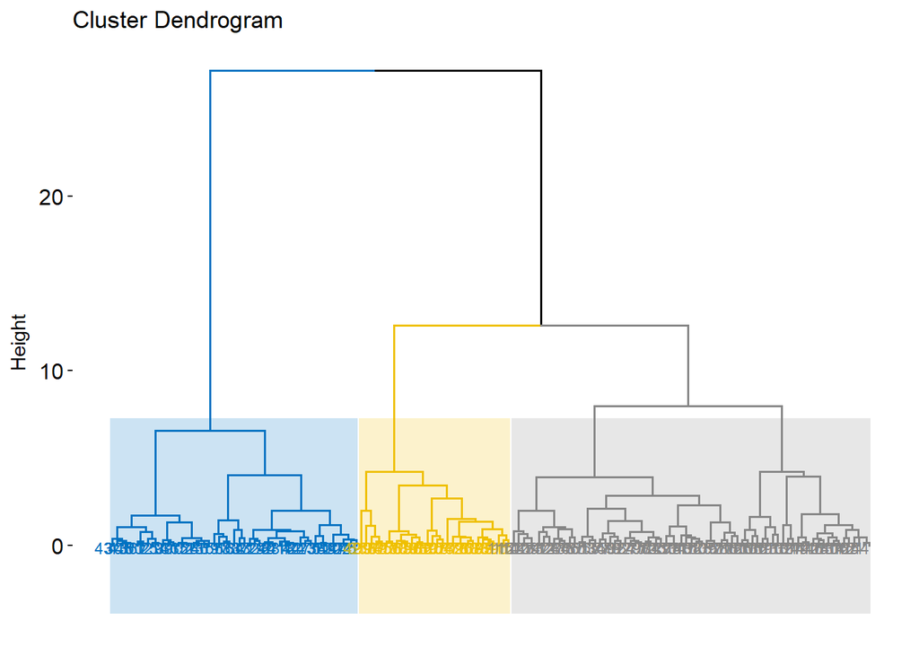

```r
df <- scale(iris[,-5])
newKmeans <- hkmeans(df,3)
fviz_dend(newKmeans, cex=0.6, palette = "jco", rect = TRUE, rect_border = "jco", rect_fill = TRUE)
```

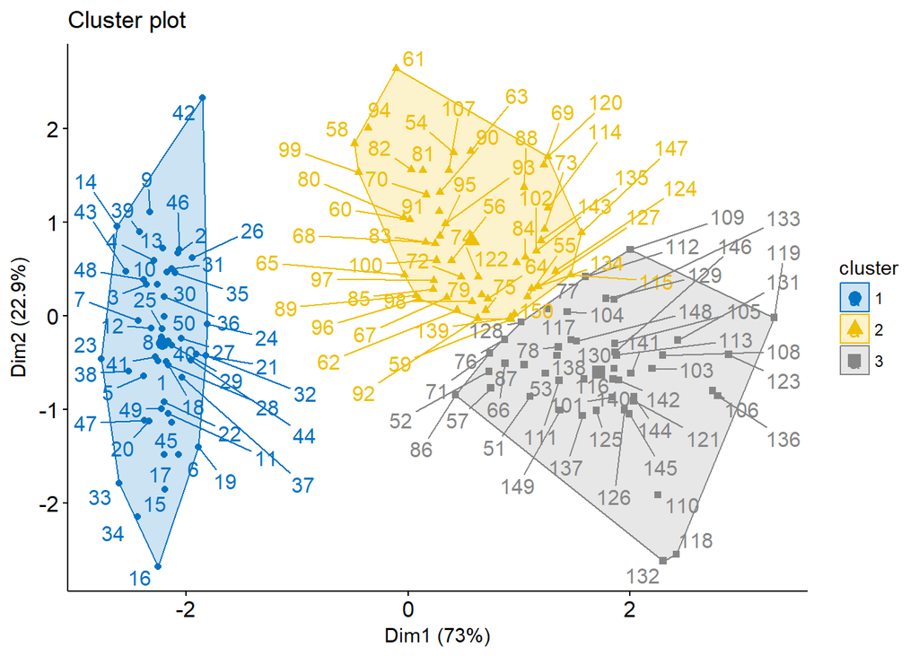

```r
fviz_cluster(newKmeans, palette="jco", repel=TRUE, ggtheme=theme_classic())
```

### Fuzzy Clustering

Fuzzy Clustering is considered as soft clustering where each element has a probability of belonging to each cluster. Each element has a set of coefficients corresponding to the degree of being in each cluster. This is different from K-Means clustering where each object is associated to one cluster only.

Fuzzy C-Means (FCM) is the most widely used fuzzy clustering algorithm. *fanny()*, part of the cluster package, is used to compute fuzzy clustering.

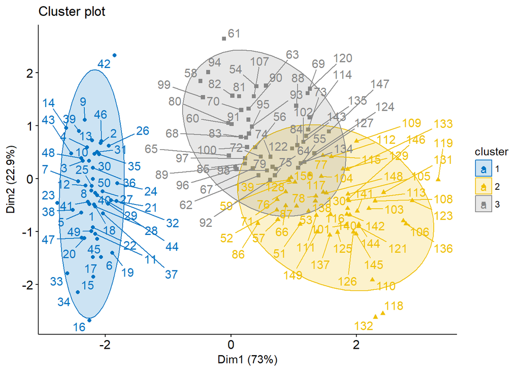

```r
fuzzy <- fanny(df, 3)# fuzzy clustering with k=3
fviz_cluster(fuzzy, ellipse.type = "norm", repel = TRUE, palette="jco", ggtheme=theme_classic(), lengend="right")
```

```
##   cluster size ave.sil.width
## 1       1   50          0.63
## 2       2   51          0.33
## 3       3   49          0.41
```

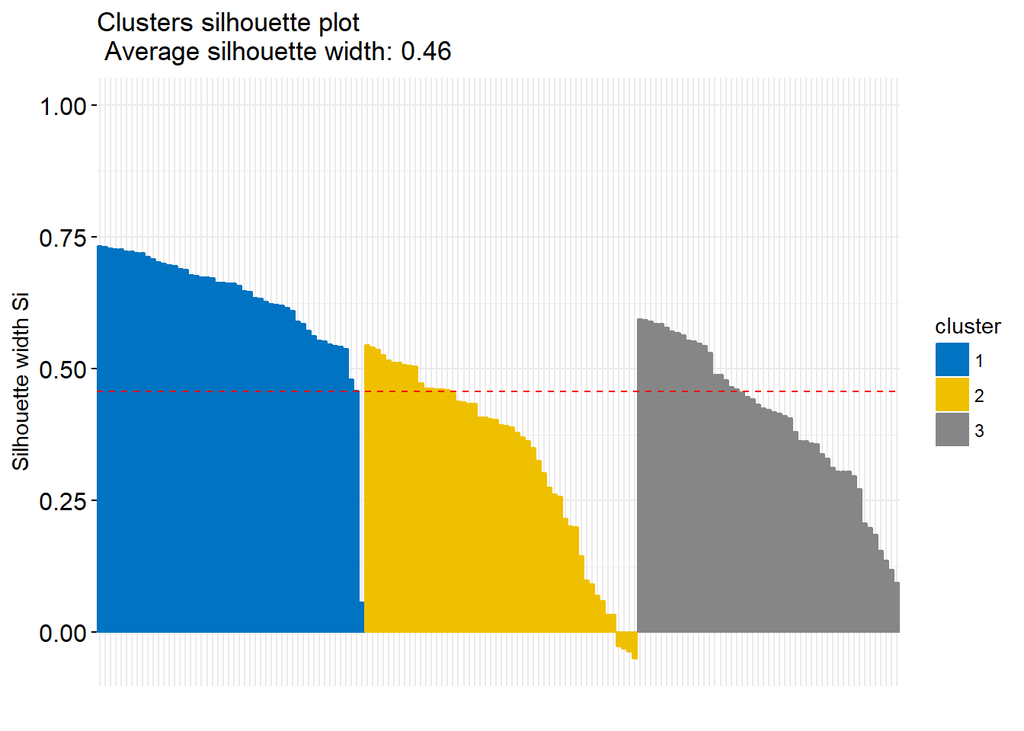

```r
fviz_silhouette(fuzzy, palette="jco", ggtheme=theme_minimal())
```

### Density Based Clustering

DBSAN (Density-Based Spatial Clustering and Application with Noise) is a popular density clustering algorithm. Density Clustering is useful when the clusters might be irregularly shaped.

We will use a different data set to illustrate this.

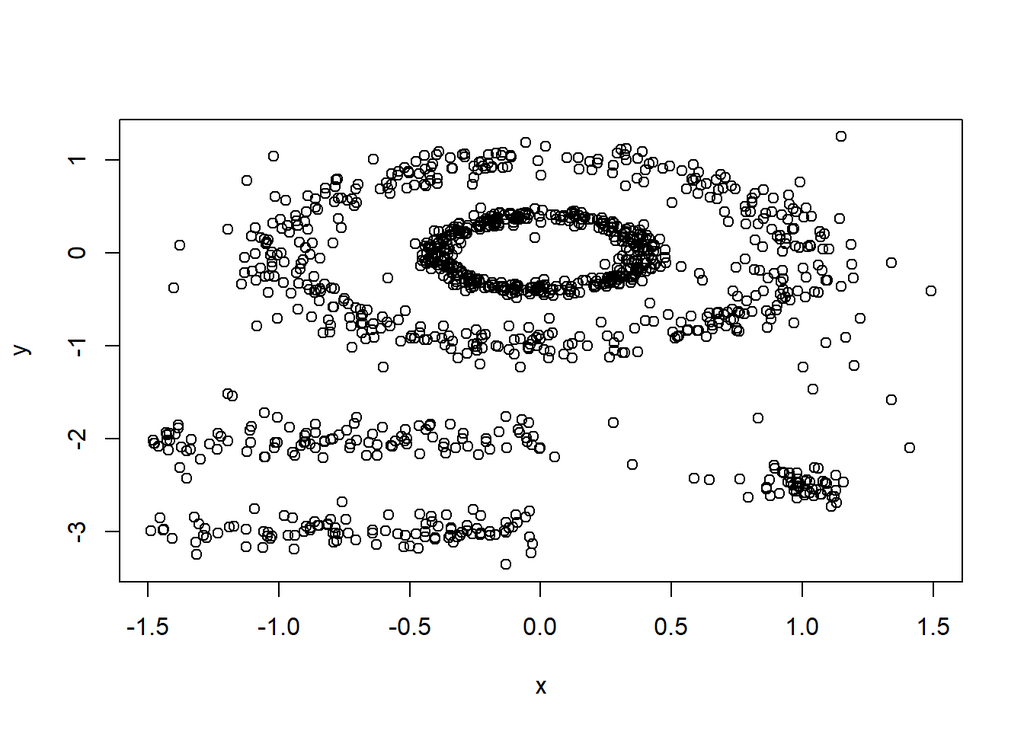

```r
df2 <- multishapes[1:2]
plot(df2)
```

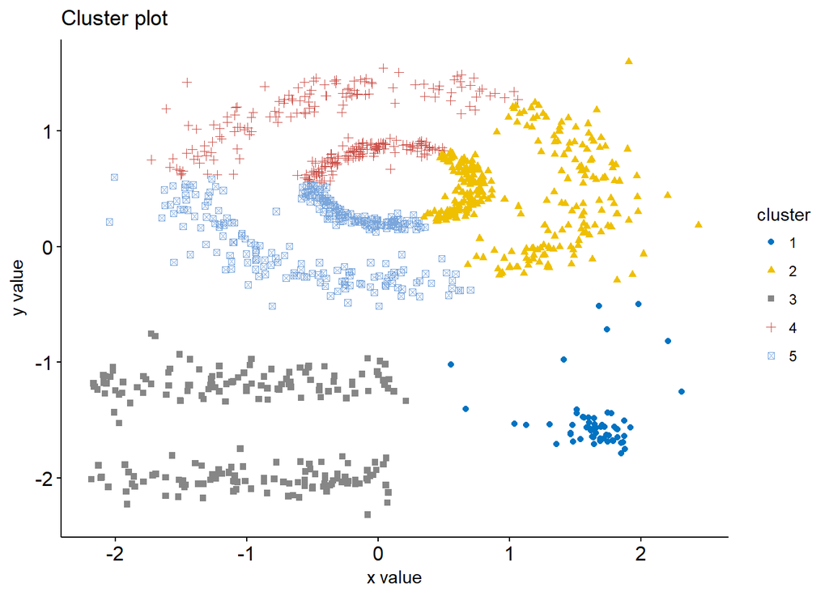

```r
km <- kmeans(df2, 5, nstart=25)
fviz_cluster(km, df2, geom = "point", ellipse = FALSE, show.clust.cent = FALSE, palette="jco", ggtheme=theme_classic())
```

Using K-Means above inaccurately identifies the 5 clusters we know to exist.

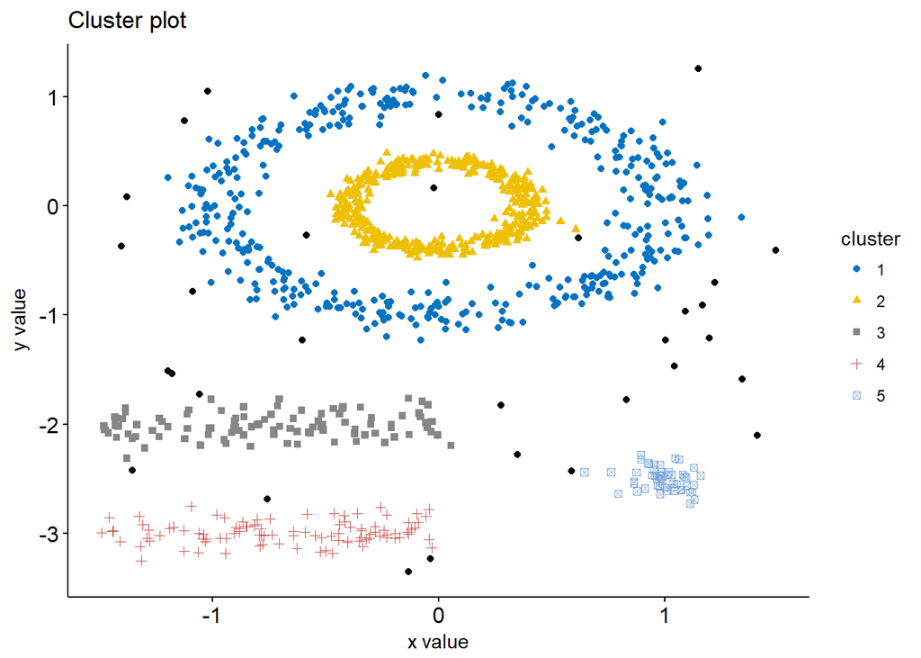

```r
mydbscan <- dbscan(df2, eps=0.15, MinPts=5)
fviz_cluster(mydbscan, df2, stand=FALSE, ellipse = FALSE, show.clust.cent = FALSE, geom = "point", palette="jco", ggtheme=theme_classic())
```

The results of dbscan are available to review:

```r
print(mydbscan)
```

```
## dbscan Pts=1100 MinPts=5 eps=0.15
##         0   1   2   3  4  5
## border 31  24   1   5  7  1
## seed    0 386 404  99 92 50
## total  31 410 405 104 99 51
```

The column name 0 above indicates the outliers.

`dbscan` requires users to specify the optimal *eps* values and the parameter *MinPts*. How do you define these? (MinPts you simply manually adjust.)

There is a function to help identify the *eps* value:

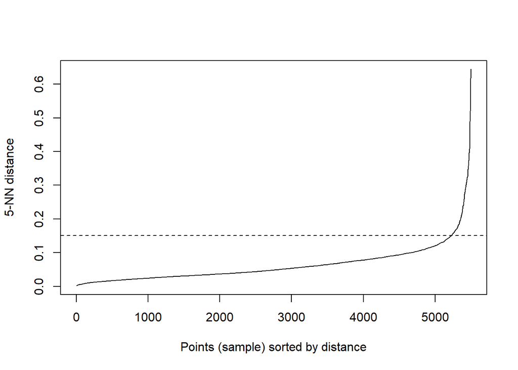

```r
dbscan::kNNdistplot(df2, k=5)
abline(h=0.15, lty=2)
```

I added the horizontal line for emphasis. You can see that the elbow appears to be close to y=0.15.

> In the fpc package, a function called *predict.dbscan* is available to make predictions on new data using the format: predict.dbscan(object, data, newdata)